# Temperature Changes at Ewa Plantation on O`ahu

Kelli Kokame

2/6/2017

## First, let’s introduce data for the Ewa Plantation Station on O`ahu

After downloading a dataset off of NOAA’s climate database, we inputted it into R for processing. This dataset includes variables like maxmimum temperature, minimum temperature, and precipitation.

## Now let’s check our data.

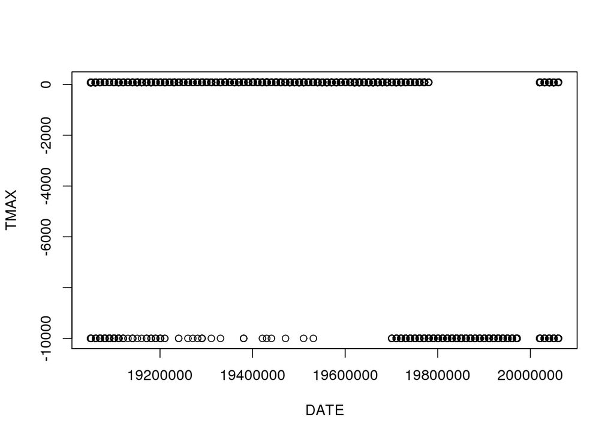

As you can see, there are several values that don’t make sense. How could the maximum temperature be almost -10000 degrees? It’s actually not—the value -9999 is used to represent having no data. We can change these values to “NA” to ensure that the big negative values do not skew our data.

Okay, now we’ll check again, for dates less then Dec. 31, 1913:

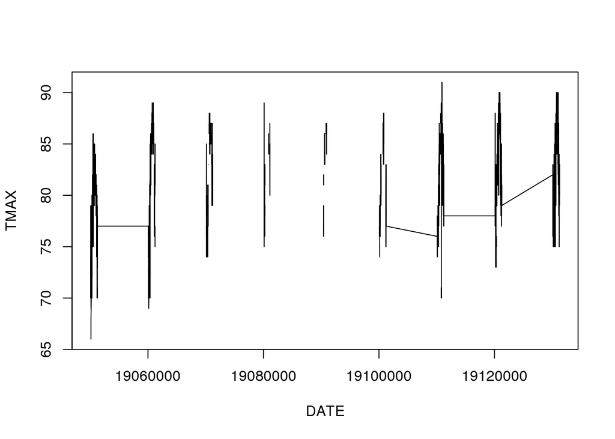

Yikes! What’s wrong? As it turns it the problem is that with how the dates are specified. In particular, the Dec 31 to Jan 1 transition:

19131231 -> 19140101, if you use these as numbers it should be 19131232, 19131232, etc. You see we are missing lots numbers!

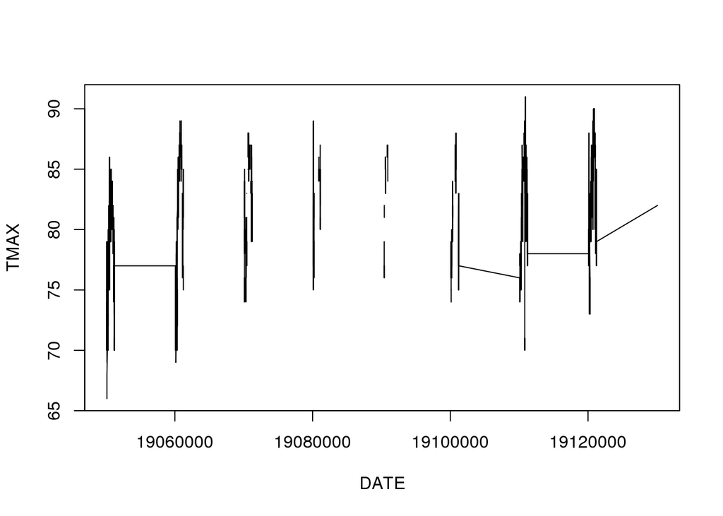

## Fixing the Dates

First, we convert the date a string or character values. Next, we’ll convert the strings to a data format.

```
## [1] "19050101" "19050102" "19050103" "19050104" "19050105" "19050106"
```

## Checking the New Dates

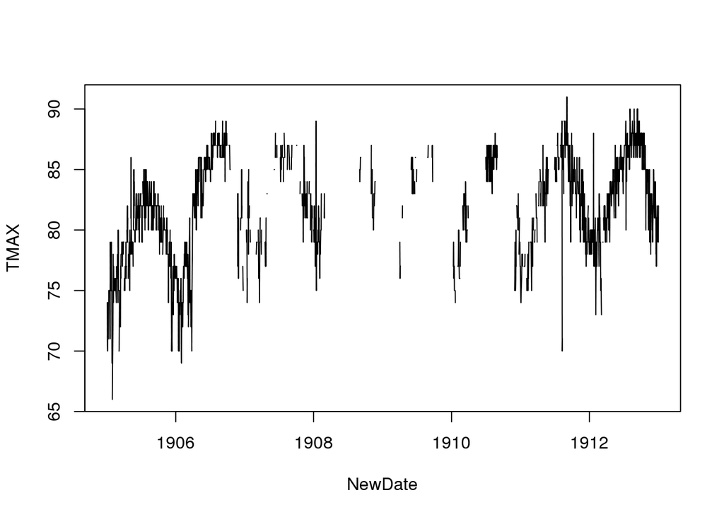

## Subset Sites

```
## [1] EWA PLANTATION 741 HI US
## Levels: EWA PLANTATION 741 HI US
```

Let’s choose EWA PLANTATION 741 HI US as the station name…

## A new plot

```
##
## Call:
## lm(formula = TMAX ~ NewDate, data = Ewa)
##
## Residuals:
##      Min       1Q   Median       3Q      Max
## -19.0590  -2.5163   0.3007   2.9257   9.1843
##
## Coefficients:
##              Estimate Std. Error t value Pr(>|t|)
## (Intercept) 8.414e+01  3.286e-02 2560.28   <2e-16 ***
## NewDate     3.097e-05  2.645e-06   11.71   <2e-16 ***
## ---
## Signif. codes:  0 '***' 0.001 '**' 0.01 '*' 0.05 '.' 0.1 ' ' 1
##
## Residual standard error: 3.589 on 25580 degrees of freedom
##   (9006 observations deleted due to missingness)
## Multiple R-squared:  0.00533,    Adjusted R-squared:  0.005291
## F-statistic: 137.1 on 1 and 25580 DF,  p-value: < 2.2e-16
```

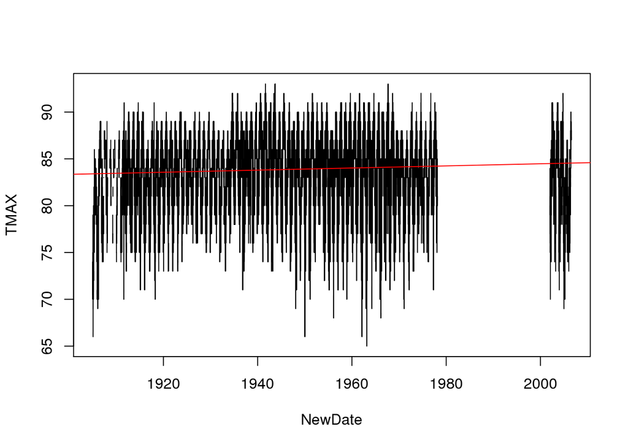

```
##
## Call:
## lm(formula = TMAX ~ NewDate, data = Ewa)
##
## Residuals:
##      Min       1Q   Median       3Q      Max
## -19.0590  -2.5163   0.3007   2.9257   9.1843
##
## Coefficients:
##              Estimate Std. Error t value Pr(>|t|)
## (Intercept) 8.414e+01  3.286e-02 2560.28   <2e-16 ***
## NewDate     3.097e-05  2.645e-06   11.71   <2e-16 ***
## ---
## Signif. codes:  0 '***' 0.001 '**' 0.01 '*' 0.05 '.' 0.1 ' ' 1
##
## Residual standard error: 3.589 on 25580 degrees of freedom
##   (9006 observations deleted due to missingness)
## Multiple R-squared:  0.00533,    Adjusted R-squared:  0.005291
## F-statistic: 137.1 on 1 and 25580 DF,  p-value: < 2.2e-16
```

Since there’s a lot of missing data beginning at roughly 1980, let us focus on the trend from roughly 1900 up until that point to see if the missing data has an effect on the trend slope.

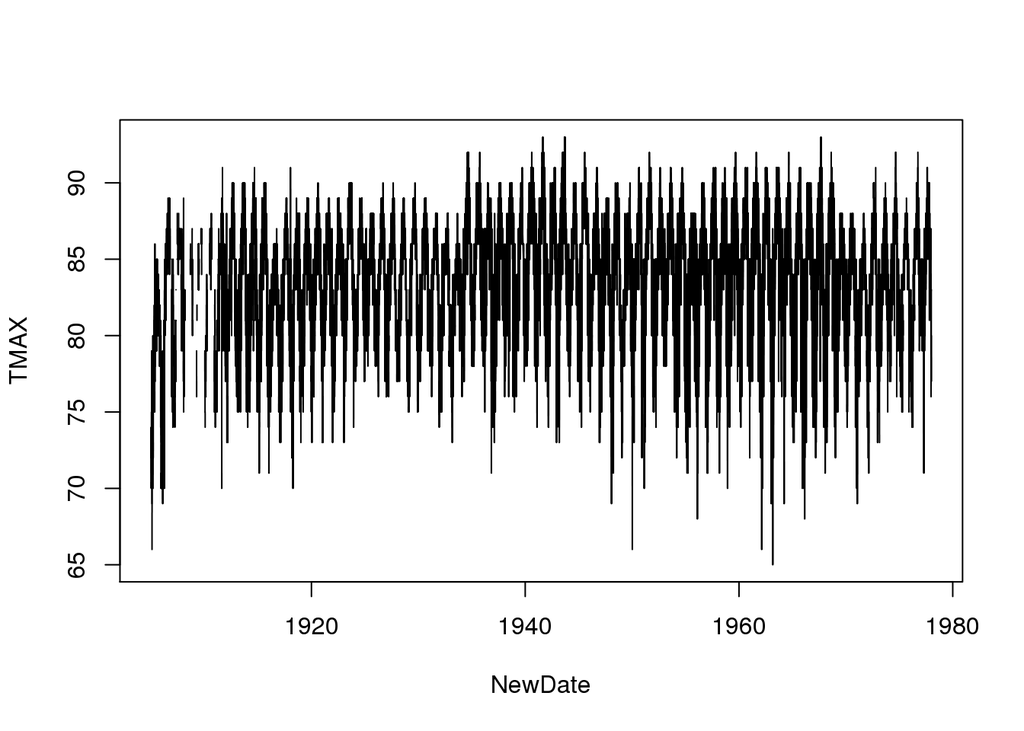

## Evaluating the trend

Creating a linear model and then evaluate the rate (slope).

```
##
## Call:
## lm(formula = TMAX ~ NewDate, data = Ewa[Ewa$DATE < 19780101,
##     ])
##
## Residuals:
##      Min       1Q   Median       3Q      Max
## -19.4039  -2.4252   0.3501   2.7643   9.1120
##
## Coefficients:
##              Estimate Std. Error t value Pr(>|t|)
## (Intercept) 8.457e+01  3.892e-02 2172.87   <2e-16 ***
## NewDate     6.565e-05  3.132e-06   20.96   <2e-16 ***
## ---
## Signif. codes:  0 '***' 0.001 '**' 0.01 '*' 0.05 '.' 0.1 ' ' 1
##
## Residual standard error: 3.539 on 24399 degrees of freedom
##   (1565 observations deleted due to missingness)
## Multiple R-squared:  0.01769,    Adjusted R-squared:  0.01765
## F-statistic: 439.4 on 1 and 24399 DF,  p-value: < 2.2e-16
```

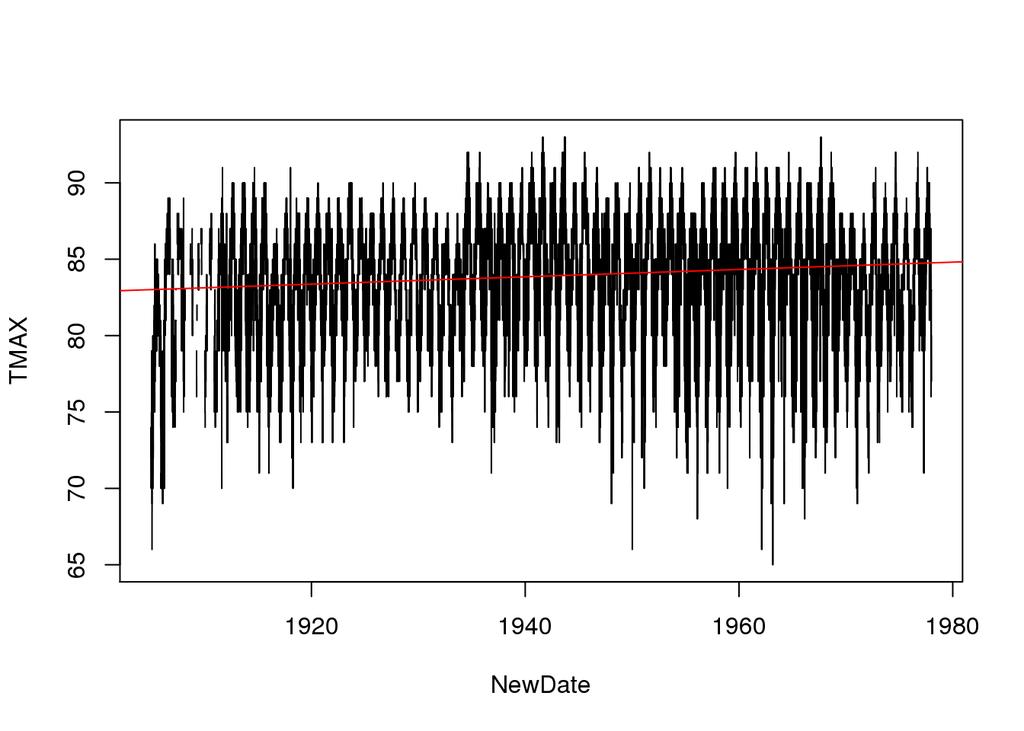

```
##
## Call:
## lm(formula = TMIN ~ NewDate, data = Ewa[Ewa$DATE < 19780101,
##     ])
##
## Residuals:
##      Min       1Q   Median       3Q      Max
## -18.1094  -2.5150   0.4151   2.7712  14.6404
##
## Coefficients:
##              Estimate Std. Error t value Pr(>|t|)
## (Intercept) 6.560e+01  4.403e-02 1489.90   <2e-16 ***
## NewDate     5.783e-05  3.517e-06   16.45   <2e-16 ***
## ---
## Signif. codes:  0 '***' 0.001 '**' 0.01 '*' 0.05 '.' 0.1 ' ' 1
##
## Residual standard error: 4.012 on 24531 degrees of freedom
##   (1433 observations deleted due to missingness)
## Multiple R-squared:  0.01091,    Adjusted R-squared:  0.01086
## F-statistic: 270.5 on 1 and 24531 DF,  p-value: < 2.2e-16
```

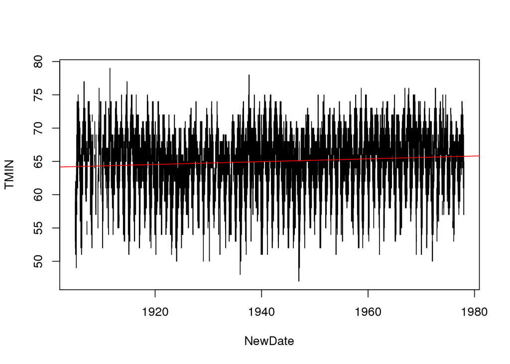

## Creating Month and Year Variables

So, let’s figure out how to see how changes happen for individual months.

### Creating Monthly Means

[output not shown]

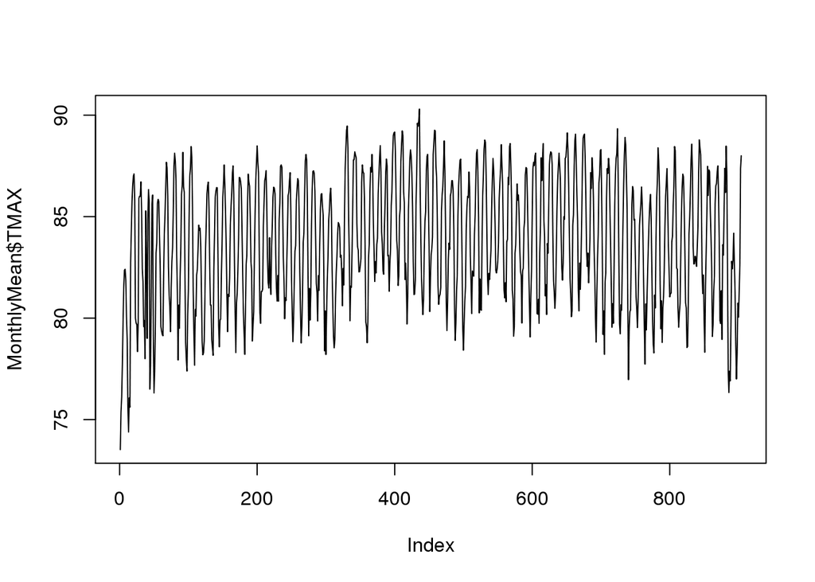

below is sd

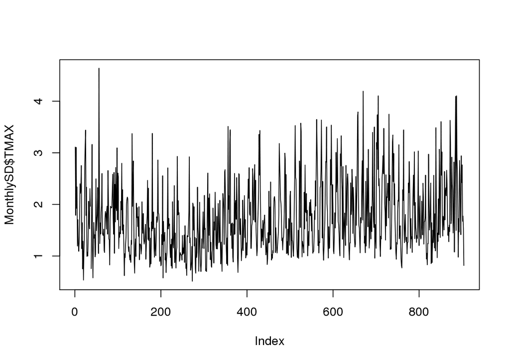

```
##
## Call:
## lm(formula = TMAX ~ NewDate, data = MonthlySD)
##
## Residuals:
##     Min      1Q  Median      3Q     Max
## -1.2849 -0.5255 -0.1560  0.4021  3.1189
##
## Coefficients:
##               Estimate Std. Error t value Pr(>|t|)
## (Intercept) -1.020e+01  1.753e+00  -5.818 8.26e-09 ***
## NewDate      6.129e-03  9.004e-04   6.807 1.81e-11 ***
## ---
## Signif. codes:  0 '***' 0.001 '**' 0.01 '*' 0.05 '.' 0.1 ' ' 1
##
## Residual standard error: 0.6746 on 901 degrees of freedom
##   (1 observation deleted due to missingness)
## Multiple R-squared:  0.04891,    Adjusted R-squared:  0.04786
## F-statistic: 46.34 on 1 and 901 DF,  p-value: 1.815e-11
```

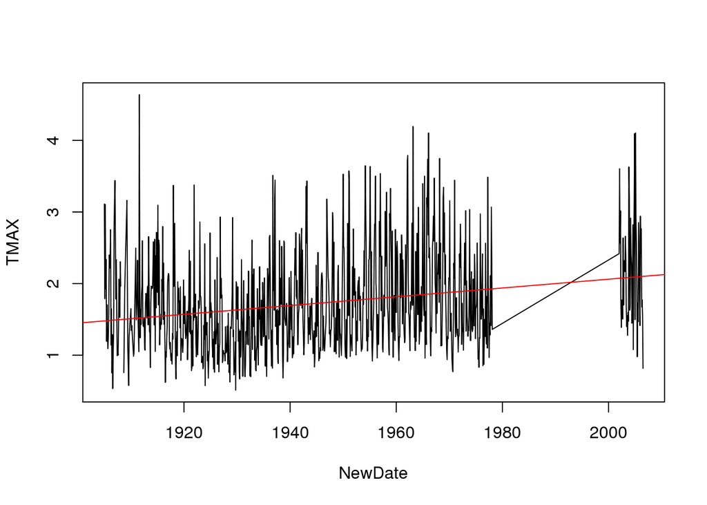

### Selecting for 1 Month – May

Perhaps, we can get a better handle on this stuff if we analyze for just one month at a time – certainly easier to visualize!

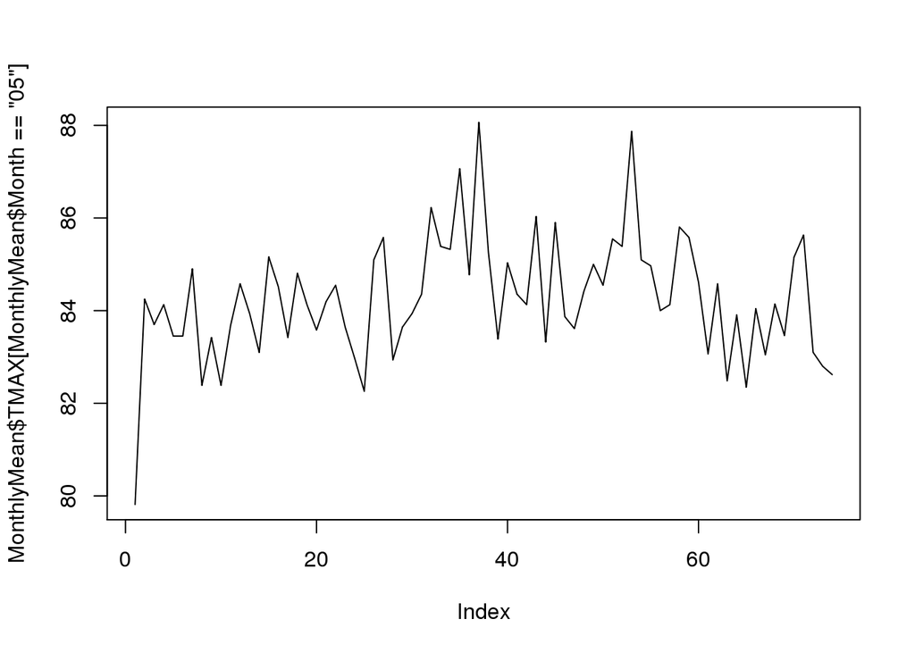

```
##
## Call:
## lm(formula = TMAX ~ YEAR, data = MonthlyMean[MonthlyMean$Month ==
##     "05", ])
##
## Residuals:
##     Min      1Q  Median      3Q     Max
## -4.1697 -0.6821  0.0274  0.7618  3.8201
##
## Coefficients:
##              Estimate Std. Error t value Pr(>|t|)
## (Intercept) 71.606844  11.945318   5.995 7.41e-08 ***
## YEAR         0.006497   0.006135   1.059    0.293
## ---
## Signif. codes:  0 '***' 0.001 '**' 0.01 '*' 0.05 '.' 0.1 ' ' 1
##
## Residual standard error: 1.307 on 72 degrees of freedom
## Multiple R-squared:  0.01534,    Adjusted R-squared:  0.001665
## F-statistic: 1.122 on 1 and 72 DF,  p-value: 0.2931
```

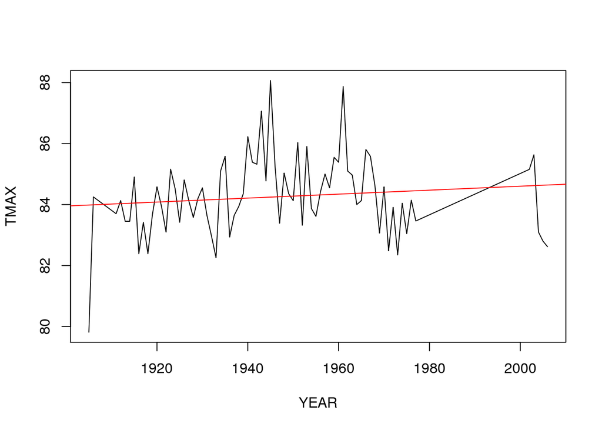

Now, the change is 0.0064974 degress/year or 0.65 degress/100 years (YIKES!) with a probability of 0.2931. Although we can’t reject the null hypothesis, it is worrying!

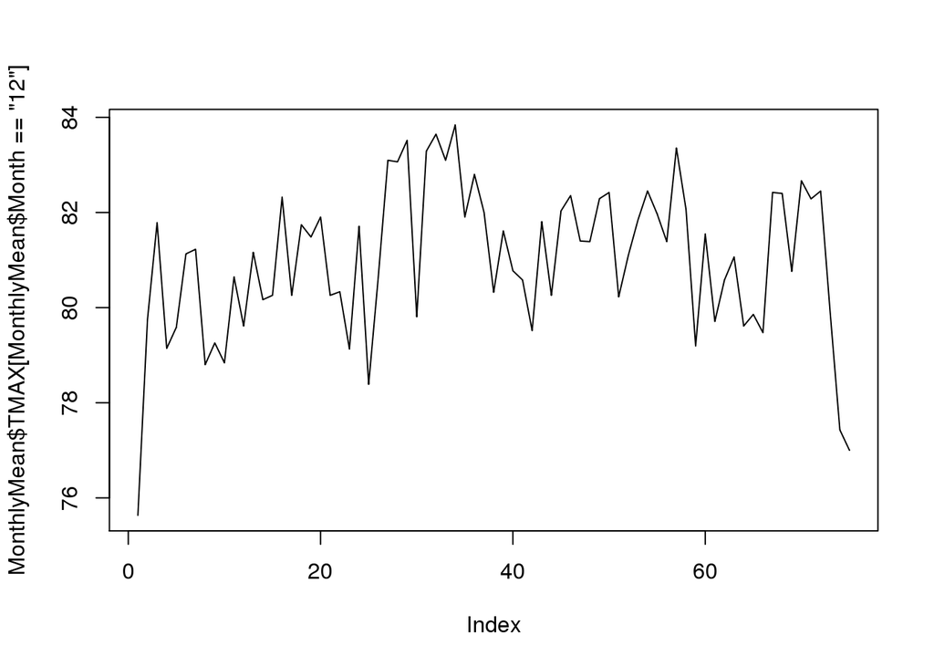

```
##
## Call:
## lm(formula = TMAX ~ YEAR, data = MonthlyMean[MonthlyMean$Month ==
##     "12", ])
##
## Residuals:
##     Min      1Q  Median      3Q     Max
## -5.1700 -1.1018  0.2921  1.0760  2.8677
##
## Coefficients:
##              Estimate Std. Error t value Pr(>|t|)
## (Intercept) 71.677975  14.760091   4.856 6.62e-06 ***
## YEAR         0.004790   0.007587   0.631     0.53
## ---
## Signif. codes:  0 '***' 0.001 '**' 0.01 '*' 0.05 '.' 0.1 ' ' 1
##
## Residual standard error: 1.602 on 73 degrees of freedom
## Multiple R-squared:  0.005431,   Adjusted R-squared:  -0.008194
## F-statistic: 0.3986 on 1 and 73 DF,  p-value: 0.5298
```

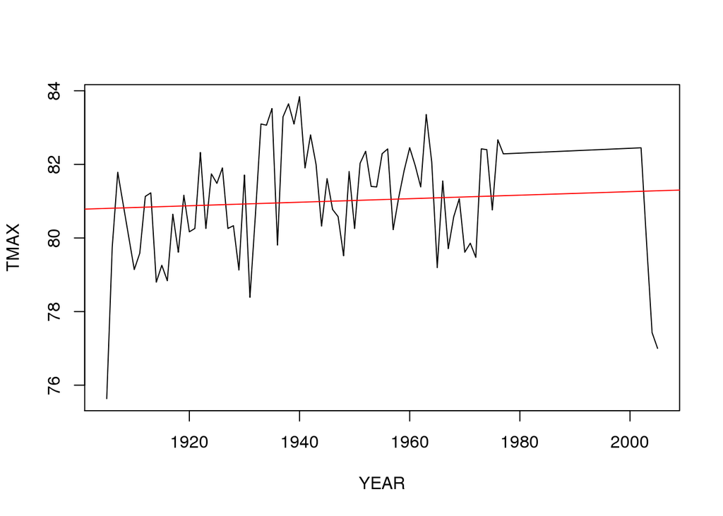

## Next Steps

I think you should evaluate every month and see what happens. You might also consider looking at the TMIN as well. Could be important!

## Lets try Dec

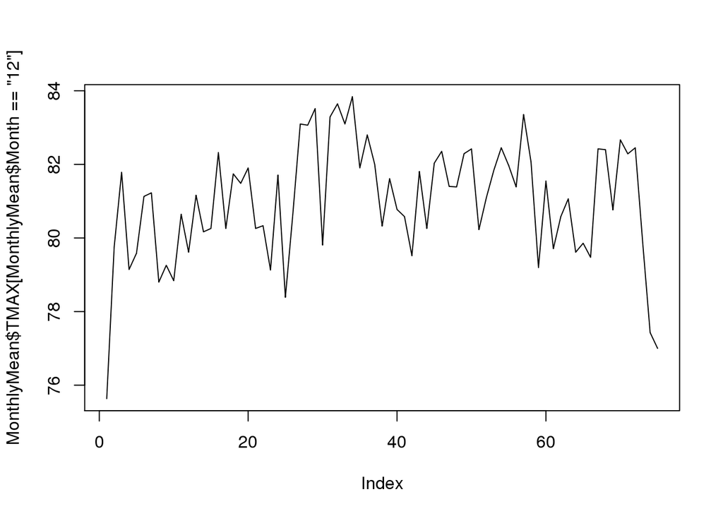

```
##
## Call:
## lm(formula = TMAX ~ YEAR, data = MonthlyMean[MonthlyMean$Month ==
##     "12", ])
##
## Residuals:
##     Min      1Q  Median      3Q     Max
## -5.1700 -1.1018  0.2921  1.0760  2.8677
##
## Coefficients:
##              Estimate Std. Error t value Pr(>|t|)
## (Intercept) 71.677975  14.760091   4.856 6.62e-06 ***
## YEAR         0.004790   0.007587   0.631     0.53
## ---
## Signif. codes:  0 '***' 0.001 '**' 0.01 '*' 0.05 '.' 0.1 ' ' 1
##
## Residual standard error: 1.602 on 73 degrees of freedom
## Multiple R-squared:  0.005431,   Adjusted R-squared:  -0.008194
## F-statistic: 0.3986 on 1 and 73 DF,  p-value: 0.5298
```

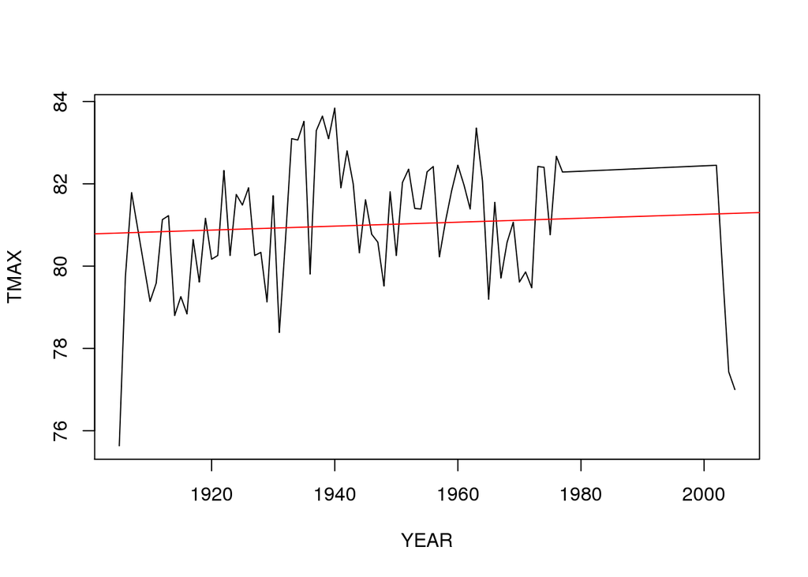

## TMIN

1. We create a monthly mean for each month.

```
##   Month Year     TMIN YEAR
## 1    01 1905 55.88000 1905
## 2    02 1905 57.33333 1905
## 3    03 1905 58.55556 1905
## 4    04 1905 62.64000 1905
## 5    05 1905 65.66667 1905
## 6    06 1905 66.32000 1905
```

2. Now we plot the mins, and again, find tons of scatter.

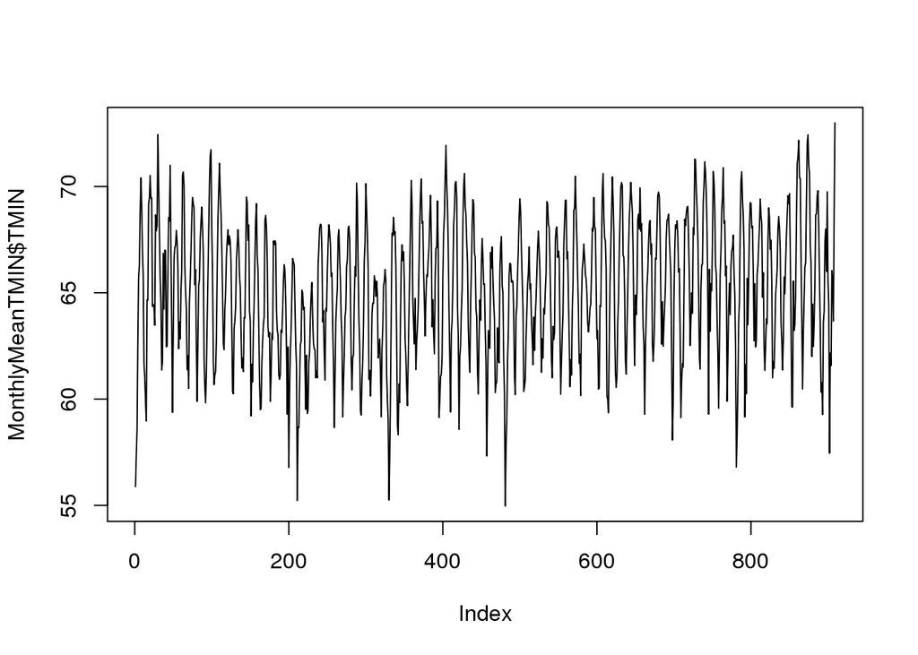

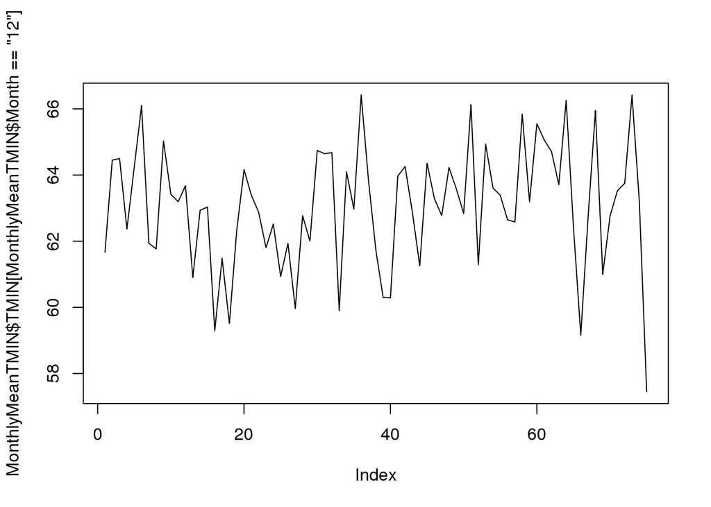

```
##
## Call:
## lm(formula = TMIN ~ YEAR, data = MonthlyMeanTMIN[MonthlyMeanTMIN$Month ==
##     "12", ])
##
## Residuals:
##     Min      1Q  Median      3Q     Max
## -5.9860 -1.0026  0.0509  1.2552  3.3937
##
## Coefficients:
##              Estimate Std. Error t value Pr(>|t|)
## (Intercept) 50.377943  17.172180   2.934  0.00447 **
## YEAR         0.006513   0.008827   0.738  0.46300
## ---
## Signif. codes:  0 '***' 0.001 '**' 0.01 '*' 0.05 '.' 0.1 ' ' 1
##
## Residual standard error: 1.864 on 73 degrees of freedom
## Multiple R-squared:  0.007402,   Adjusted R-squared:  -0.006196
## F-statistic: 0.5443 on 1 and 73 DF,  p-value: 0.463
```

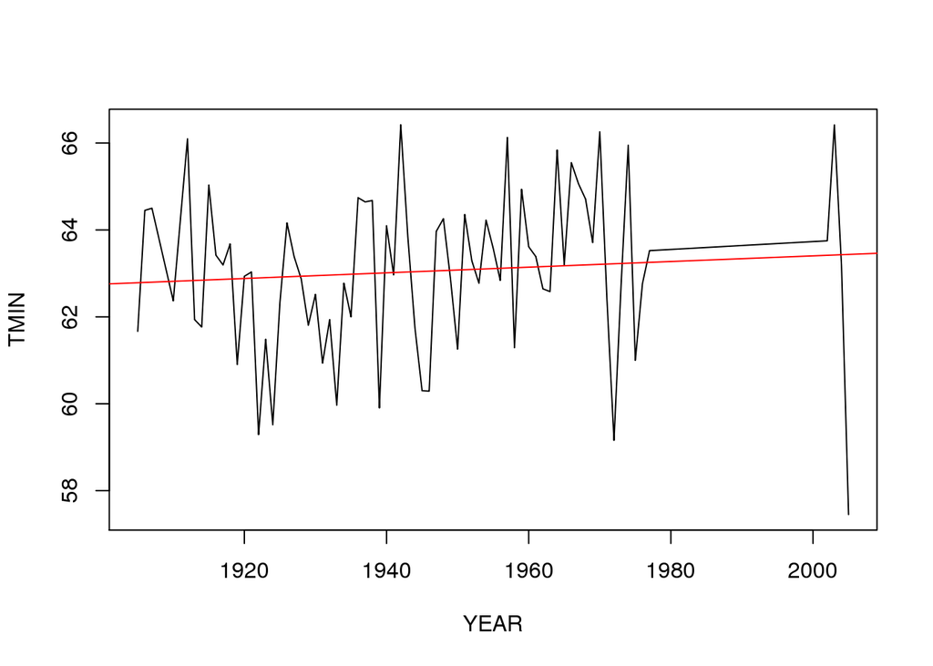

# Departure from Mean

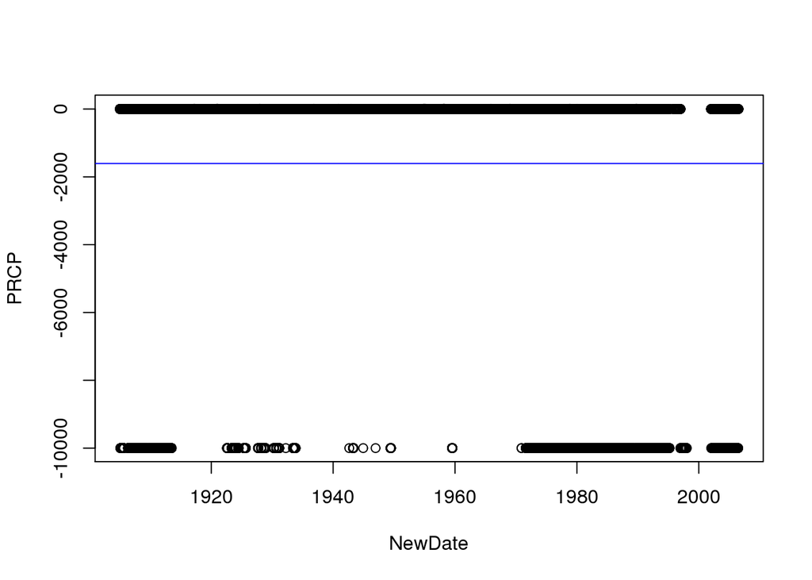

## Experimental Portion — Precipitation

Precipiation might depend more on the departure from the mean (often referred as as normal, whatever that means!). I think it’s worth pursuing, but haven’t finished the analysis yet.

Second, we need to remove the missing values and evalaute which years have complete years. If you are missing rainy months, then the whole year should be thrown out – but what about partial years in the drought season?

Third, we will need to decide what level of aggredation – monthly, yearly, etc.

Fourth, in CA the water year starts in Oct 1. Should we follow the same convention?

A yearly mean, based on the annual sum for the entire records. Not sure this is appropriate.

Figure has points of the yearly sum of rainfall and the blue line mean. The greenline is the trend and red line is a five year running average, I think! I am still trying to understand what the code is doing.

```
## [1] 0.2 0.2 0.2 0.2 0.2
```

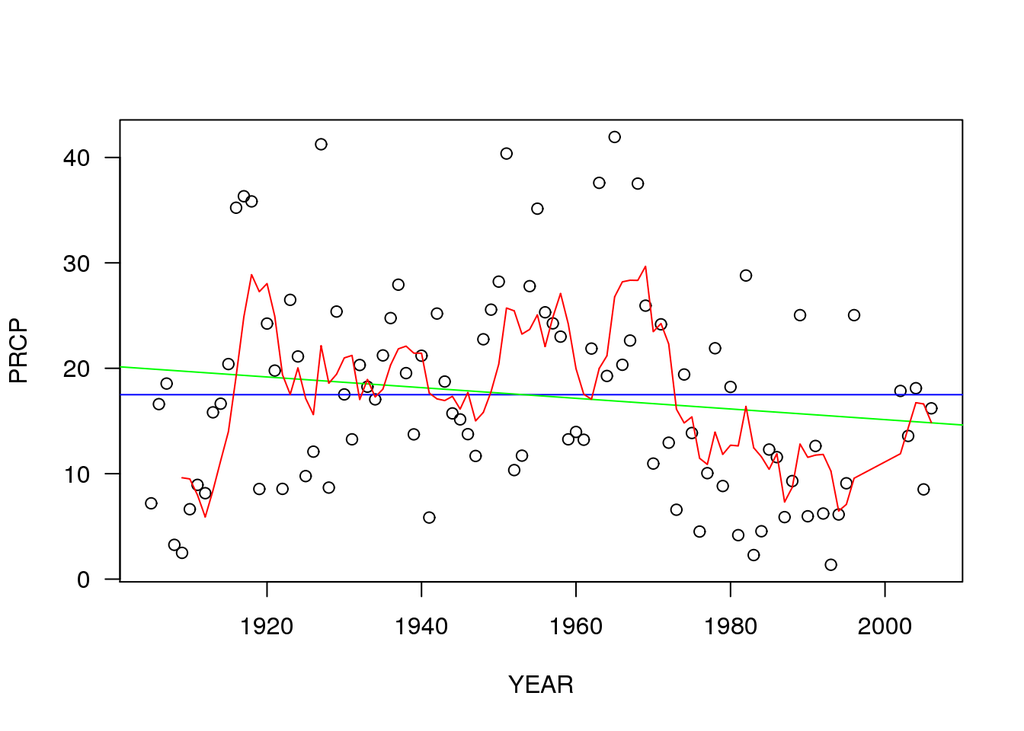

The model suggests that the precipitation is declines at a rate of -0.0505811 cm yr$^{-1}~$, or -0.51 cm decade$^{-1}$.

```
##
## Call:
## lm(formula = PRCP ~ YEAR, data = YearlySum)
##
## Residuals:
##     Min      1Q  Median      3Q     Max
## -17.241  -6.435  -1.396   5.833  25.042
##
## Coefficients:
##              Estimate Std. Error t value Pr(>|t|)
## (Intercept) 116.29024   66.55684   1.747   0.0838 .
## YEAR         -0.05058    0.03407  -1.485   0.1410
## ---
## Signif. codes:  0 '***' 0.001 '**' 0.01 '*' 0.05 '.' 0.1 ' ' 1
##
## Residual standard error: 9.544 on 95 degrees of freedom
## Multiple R-squared:  0.02267,    Adjusted R-squared:  0.01239
## F-statistic: 2.204 on 1 and 95 DF,  p-value: 0.141
```

Other attempts that didn’t work!

```
##  Time-Series [1:97, 1] from 1 to 97: 7.19 16.6 18.55 3.25 2.49 ...
##  - attr(*, "dimnames")=List of 2
##   ..$ : NULL
##   ..$ : chr "PRCP"
```

yearlyts.lag = lag(yearlyts, 5)[6:112,]; head(yearlyts.lag)

plot(yearlyts, lty = 1, col = 3)

lines(yearlyts.lag)

lines(Departure ~ YEAR, data=YearlySum, col=“red”)